# examples_0309

You can use this tool:

https://artockthedino.github.io/pbl/spirolateral/spirolateral_generator.html

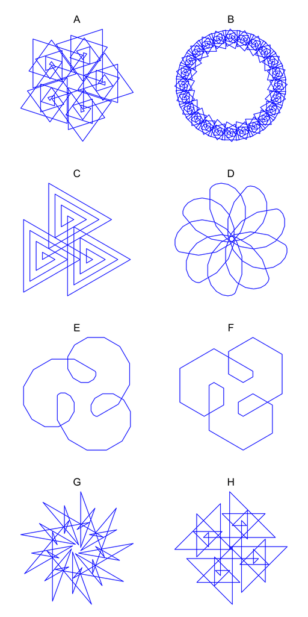

ABCDEFGH

The correct answer is H.

Below I've listed the parameters used to generate all patterns:

- A:
  - Turn angle = 108
  - Count max = 16

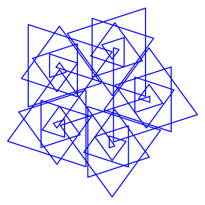

- B:
  - Turn angle = 105
  - Count max = 17

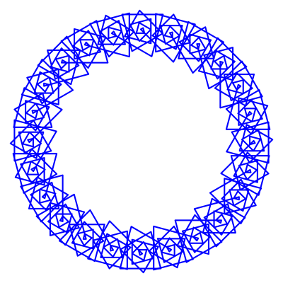

- C:
  - Turn angle = 120
  - Count max = 11

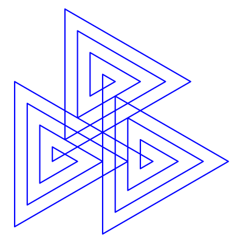

- D:
  - Turn angle = 20
  - Count max = 14

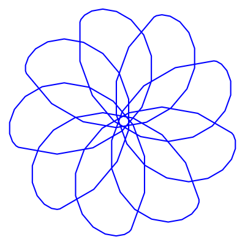

- E:
  - Turn angle = 30
  - Count max = 16

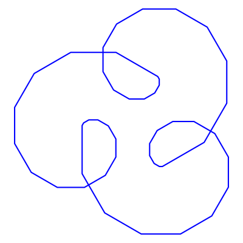

- F:
  - Turn angle = 60
  - Count max = 8

[figure not shown]

- G:
  - Turn angle = 160
  - Count max = 5

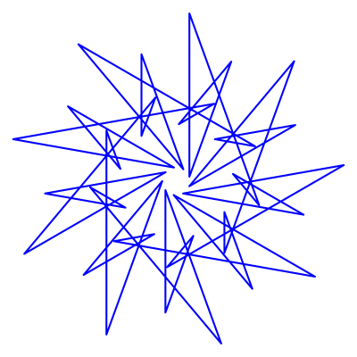

- H:
  - Turn angle = 135
  - Count max = 10

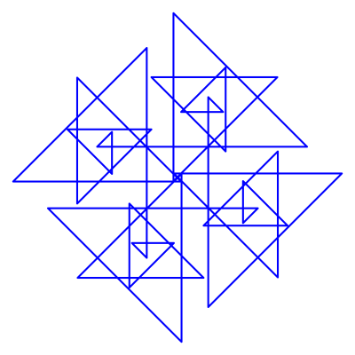

Let's say you want to make a [spirolateral](https://en.wikipedia.org/wiki/Spirolateral).

If the turn angle is $\theta=45^{\circ}$ and the maximum segment length is $n=15$, then which spirolateral is created?

You can use this tool:

https://artockthedino.github.io/pbl/spirolateral/spirolateral_generator.html

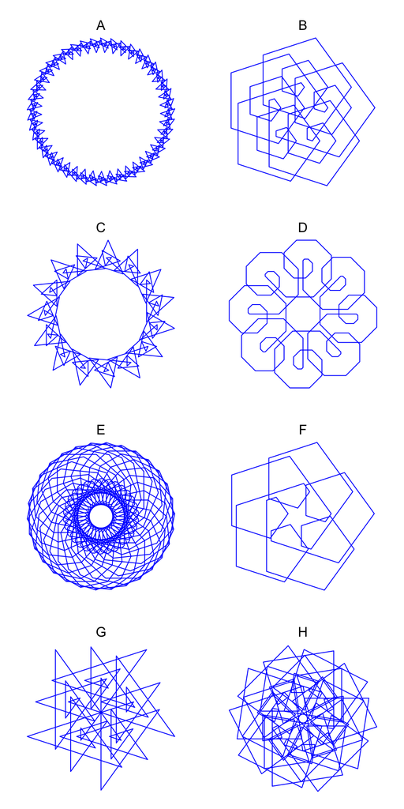

ABCDEFGH

The correct answer is D.

Below I've listed the parameters used to generate all patterns:

- A:
  - Turn angle = 136
  - Count max = 8

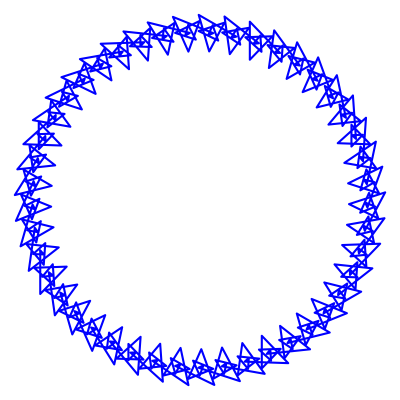

- B:
  - Turn angle = 72
  - Count max = 12

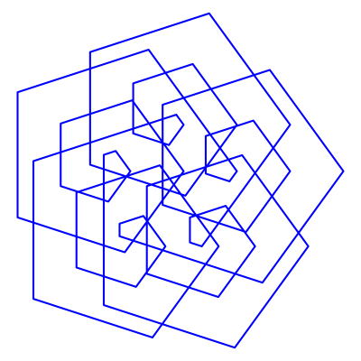

- C:
  - Turn angle = 132
  - Count max = 8

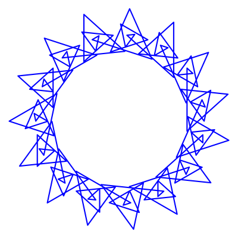

- D:
  - Turn angle = 45
  - Count max = 15

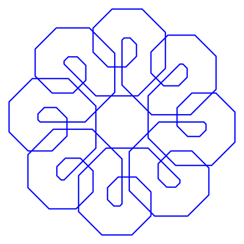

- E:
  - Turn angle = 42
  - Count max = 14

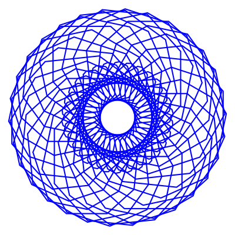

- F:
  - Turn angle = 72
  - Count max = 7

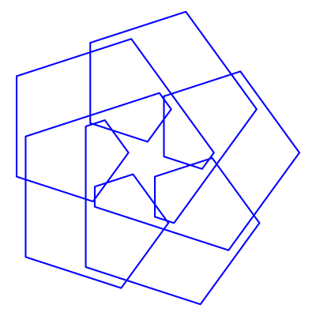

- G:
  - Turn angle = 144
  - Count max = 9

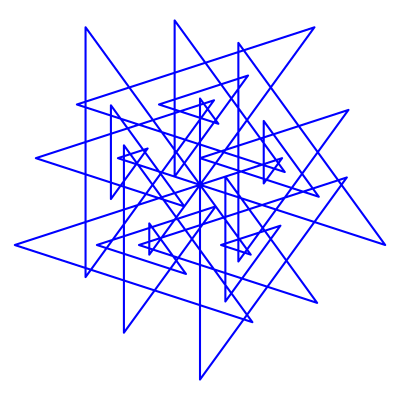

- H:
  - Turn angle = 99
  - Count max = 12

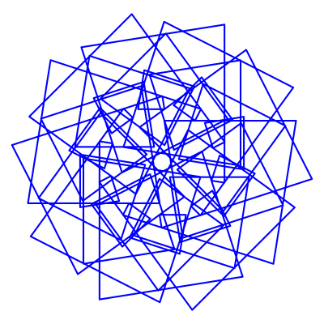

Let's say you want to make a [spirolateral](https://en.wikipedia.org/wiki/Spirolateral).

If the turn angle is $\theta=156^{\circ}$ and the maximum segment length is $n=13$, then which spirolateral is created?

You can use this tool:

https://artockthedino.github.io/pbl/spirolateral/spirolateral_generator.html

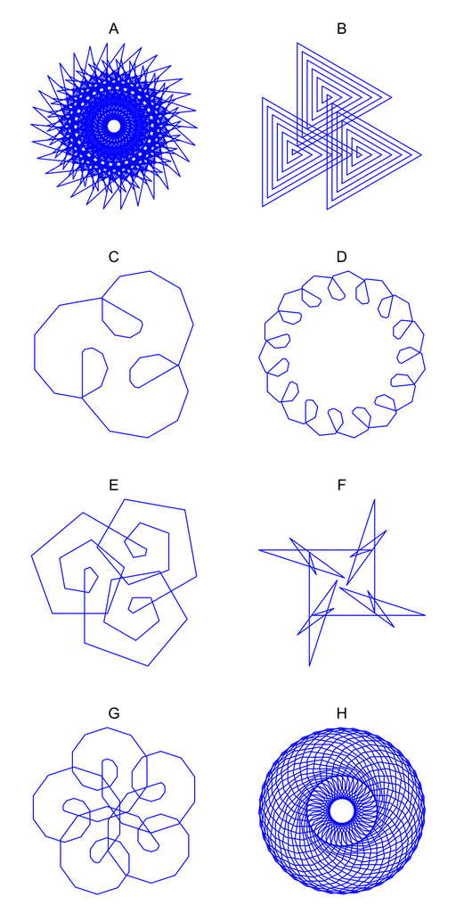

ABCDEFGH

The correct answer is A.

Below I've listed the parameters used to generate all patterns:

- A:
  - Turn angle = 156
  - Count max = 13

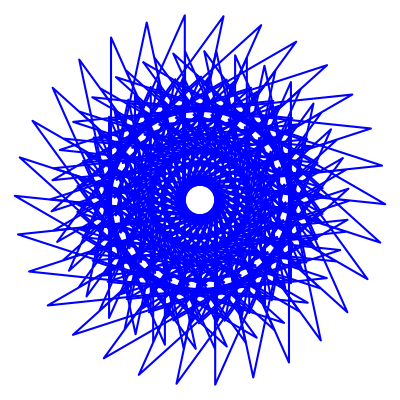

- B:
  - Turn angle = 120
  - Count max = 20

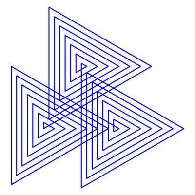

- C:
  - Turn angle = 40
  - Count max = 12

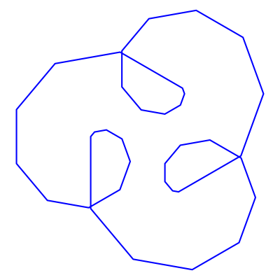

- D:
  - Turn angle = 48
  - Count max = 8

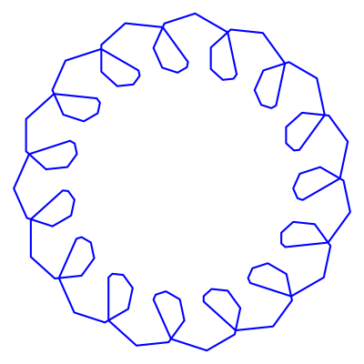

- E:
  - Turn angle = 70
  - Count max = 12

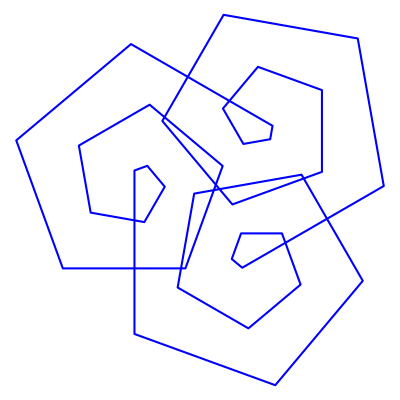

- F:
  - Turn angle = 162
  - Count max = 5

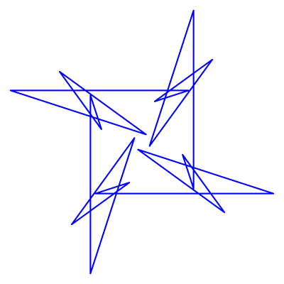

- G:
  - Turn angle = 36
  - Count max = 18

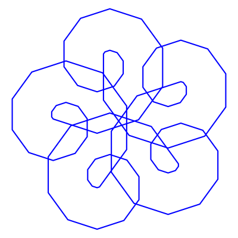

- H:
  - Turn angle = 27
  - Count max = 19

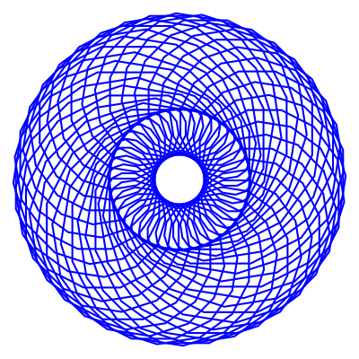

Let's say you want to make a [spirolateral](https://en.wikipedia.org/wiki/Spirolateral).

If the turn angle is $\theta=60^{\circ}$ and the maximum segment length is $n=14$, then which spirolateral is created?

You can use this tool:

https://artockthedino.github.io/pbl/spirolateral/spirolateral_generator.html

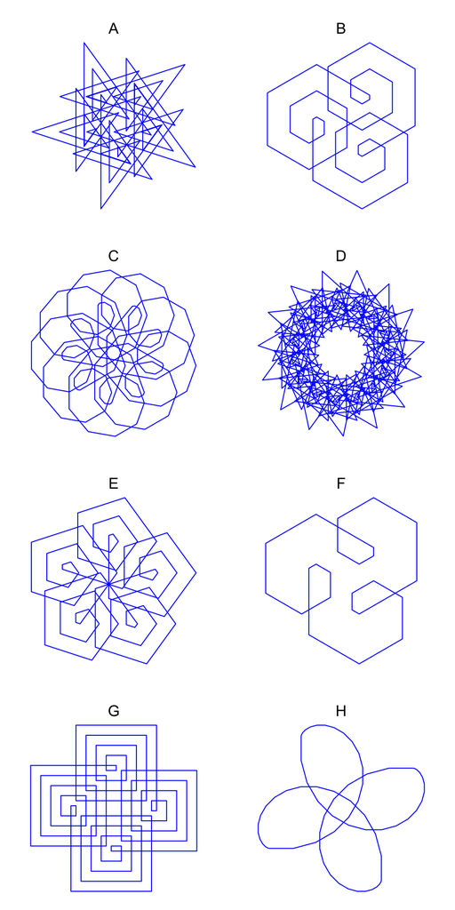

ABCDEFGH

The correct answer is B.

Below I've listed the parameters used to generate all patterns:

- A:
  - Turn angle = 144
  - Count max = 11

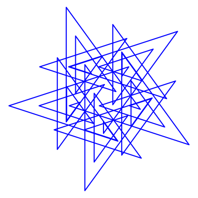

- B:
  - Turn angle = 60
  - Count max = 14

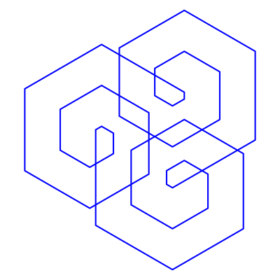

- C:
  - Turn angle = 40
  - Count max = 16

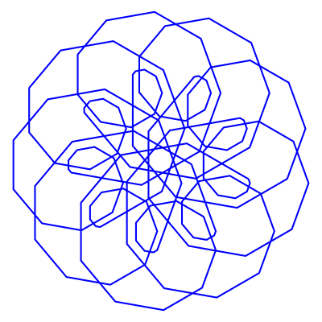

- D:
  - Turn angle = 132
  - Count max = 16

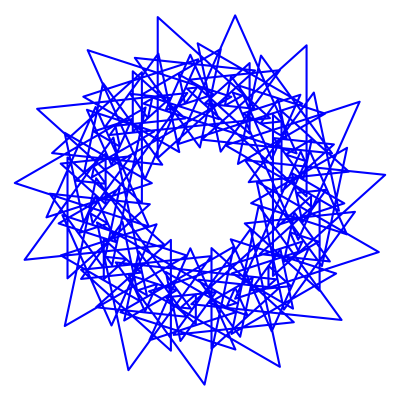

- E:
  - Turn angle = 72
  - Count max = 14

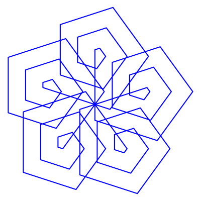

- F:
  - Turn angle = 60
  - Count max = 8

[figure not shown]

- G:
  - Turn angle = 90
  - Count max = 17

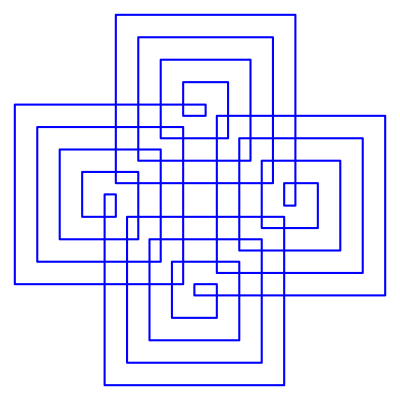

- H:
  - Turn angle = 15
  - Count max = 18

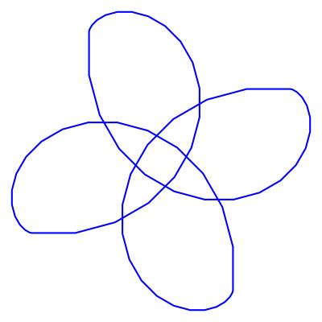

Let's say you want to make a [spirolateral](https://en.wikipedia.org/wiki/Spirolateral).

If the turn angle is $\theta=60^{\circ}$ and the maximum segment length is $n=10$, then which spirolateral is created?

You can use this tool:

https://artockthedino.github.io/pbl/spirolateral/spirolateral_generator.html

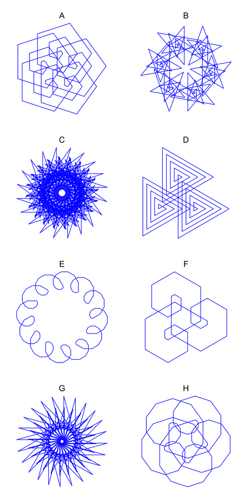

ABCDEFGH